# Presentación de R

Pepi Amodeo

Julio 2020

Tiempo de lectura aproximado: 5 minutos

Instituto Argentino de Oceanografía (CONICET)

Universidad Nacional del Sur, Bahía Blanca, Argentina

En esta clase propongo una presentación del software R para el análisis, procesamiento y visualización de datos, dirigida a aquellos que nunca usaron el software y les interesa empezar a saber de qué se trata. Muestro una breve síntesis de lo que és el software, sus posibles ventajas y desventajas.

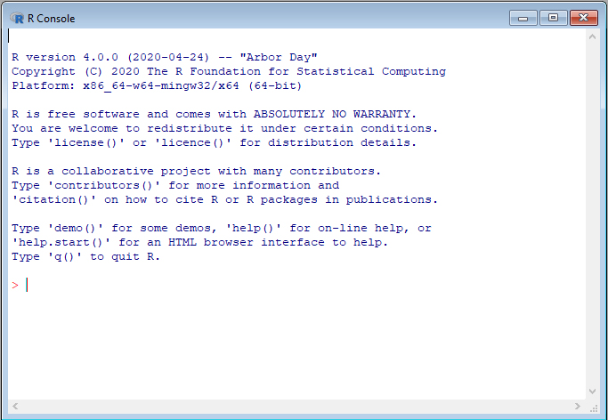

# R, un lenguaje muy apropiado para la ciencia

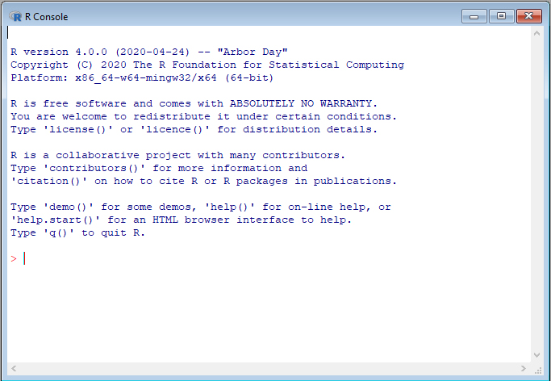

Las personas que trabajan en ciencia comúnmente utilizan programas para analizar y presentar sus datos, que normalmente presentan una interfaz gráfica simplificada, ya sea con menús, solapas, botones. Existe una gran variedad de programas y estilos, pero podemos verlos a todos como un medio para darle órdenes a un autómata (la computadora) para que realice ciertos procedimientos pre-establecidos. Para ello uno acciona procesos que fueron programados por otros (desarrolladores del software) a través de botones, tildes, celdas a completar, etc. En esta configuración, las figuras de **usuario** y **programador** se encuentran bien separadas. En algunos software, se permite un mayor o menor grado de ajuste de la herramienta a las necesidades, mediante la incorporación del uso de códigos. Esto permite al usuario ir adquiriendo la capacidad de modificar la herramienta y ajustarla a sus necesidades. El usuario así comienza a utilizar un lenguaje de programación y se empieza a desdibujar la diferencia usuario-desarrollador.

Usar R requiere que aprendas un lenguaje. Como cualquier lenguaje (español, chino, italiano, inglés), hay quienes tienen una facilidad para aprenderlos (y aprehenderlos), y hay quienes lo sufren como una pesadilla. Existen diversos perfiles de usuarios de R, y muchos de ellos no implican convertirse en un programador avanzado. El grado de dominio que vas a requerir sobre el lenguaje, va a depender de tus objetivos y necesidades. Por ejemplo, yo podría escribir un mail en chino mandarín (lenguaje que no domino) utilizando traductores y herramientas disponibles en internet. Probablemente el resultado sea bastante rudimentario y me implique mucho tiempo y frustraciòn hacerlo, pero lo lograría. Ahora bien, nunca podría atender un *call-center* en China.

El uso que vos le des y tus necesidades hacen que R valga la pena o no

Uno puede usar R como un compendio de “cajas negras” (usuario *copy/paste* o utilizar interfases gráficas de terceros), al igual que cualquier otro software, o puede indagar en mayor profundidad en lo que necesite para comprender los procesos que está llevando a cabo y dominar mejor su habilidades profesionales. Esa es una de las grandes virtudes de utilizar un lenguaje de programación para hacer tareas especializadas como analizar datos: los pasos son interpretables y reproducibles.

# Características (posibles ventajas y desventajas)

## Virtudes

- Es software libre

Es gratis, tenés licencia para usarlo y citarlo libremente. Lo podés modificar, lo podés adecuar a tus necesidades… eventualmente.

- Versatilidad

Basicamente podrías llegar a hacer cualquier cosa que se te ocurra. Desde analizar datos, hacer gráficos, programar un videojuego, componer música.

- Automatización

Permite incorporar operaciones informáticas básicas que permiten hacer procesamientos múltiples, repeticiones. Una vez que se entiende la lógica de los loops y condicionales, nunca más usás el mouse.

- Reproducibilidad (flujo de trabajo)

Quizás la principal característica que da nombre al software. Todo procedimiento es reproducible e interpretable de principio a fin por otra persona (colega, director/a, revisor/a) o por vos mismo/a unos meses (o días) después de haberlo hecho. Algo muy deseable en la ciencia, ¿no?

- Soporte comunidad

Al ser software libre y haberse popularizado tanto en el ambiente de la ciencia y del análisis de datos, la comunidad de usuarios en todo el mundo es muy grande y los recursos para consultar son prácticamente infinitos.

(R-help, StackOverflow, R-graphs, github, Rpubs…)

## Desventajas

- Curva de aprendizaje

Paciencia ante frustración al principio… Como todo lenguaje, implica una curva de aprendizaje e incorporación de hábitos. Si tratás de avanzar muy rápido, o usás material bibliográfico inadecuado, o tenés un maestro no compatible con tu forma de aprender, entonces aprender el lenguaje puede ser muy engorroso y frustrante.

Para usar R necesitás ser ordenado/a con tus procedimientos, usar el sentido común y estar dispuesto/a a ir aprendiendo un lenguaje poco a poco y estar dispuesto/a a recurrir permanentemente a material de consulta (libros, tutoriales, blogs).

Como decía anteriormente, un usuario de R puede ser alguien que corre procedimientos (análisis, gráficos). Pero además, ser usuario de R ofrece una forma de aprender a comunicarse con un autómata (la computadora) de forma conciente y que esto nos permita tener cada vez un mejor control sobre lo que hacemos, y no simplemente meter y sacar cosas de una caja negra.

- Interfase un poco ruda

Lo potente definitivamente no es elegante. Podemos estar de acuerdo en que la interfase no es lo más bello del planeta, pero es lo mejor que puede ser. Si te gustan los globos de colores podés agregárselos, es software de código abierto.

# Ejemplos

Algunas aplicaciones de R

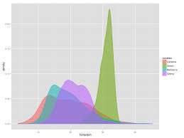

# En concreto

Si tus necesidades son simples, y no estás dispuesto a aprender un lenguaje, entonces quizás te convenga recurrir a una herramienta con interfaz gráfica más simple o alguna de las interfases gráficas de terceros para R. Estas clases apuntan a promover el aprendizaje y uso de R como un lenguaje libre, interpretable y reproducible.